# Ocena modeli uczenia maszynowego©

Notatnik wykonany przez Przemysław Budzisz & Jakub Piotrowski z grupy Z609 w roku 2022

# Wpierw krótko wyjaśniamy

## Dane dzielimy na

1. Klasyfikacyjne - jeśli dane wykorzystywane aby przypisać je do odpowiednich kategorii/grup (np. Czy jest to gruszka czy pomarańcza lub czy ktoś choruje na daną chorobę czy nie)
2. Regresyjne - jeśli chcemy przewidzieć jakąś wartość (np. wycenić mieszkanie na podstawie innych mieszkań)
3. Klasteryzacyjne - algorytmy przeznaczone do wyszukiwania wzorców (np. rekomendacja produktów)

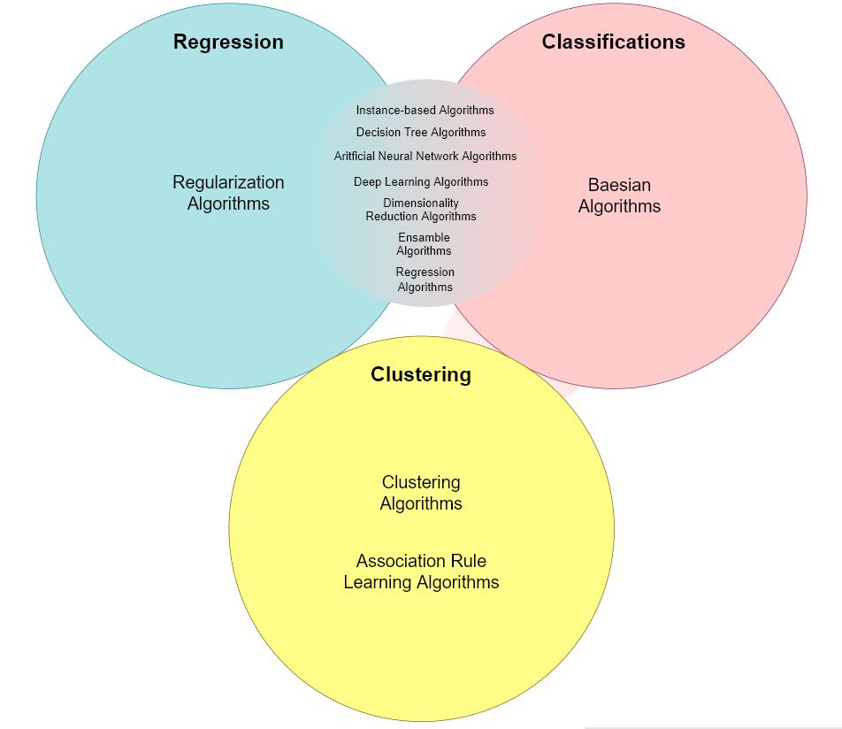

```python
from PIL import Image

try:
    img  = Image.open("F:\\STUDIA\\6SEM\\zpiid\\podzial_danych.png")
except IOError:
    pass

img
```

## Lekkie oszustwo co kosztowało nas nerwy:

Algorytm o nazwie Logistic Regression nadaje się tylko do zadań klasyfikacji

## Nasze rozumowanie diagramu

W grupie Regularization Algorithms zwiera się kilka algorytmów (link 1. w Źródłach). Wszystkie one służą tylko i wyłącznie do realizacji zadań regresji. W grupie Regression Algorithms jest model Logistic Regression i nawet pomimmo jego nazwy "Regression" służy on do klasyfikacji. Wniosek: Niektóre algorytmy mogą służyć do różnych zadań, ale zawierają się w danej grupie, więc żeby nie wylewać tekstu na ekran postanowiliśmy to pogrupować i przypisać do odpowiednich kategorii.

## Ocenianie

Do obliczania "jakości" zbiorów i tego jakie zmiany w nich wprowadziliśmy stosuje się odpowiednie metryki. Rodzielane są one między 3 kategorie widoczne na diagramie

## Dobór algorytmów

Algorytmy użyte do testowania danych (regresja):

1. LinearRegression()
2. RidgeRegression()
3. DecisionTreeRegressor()
4. RandomForestRegression()
5. KNeighborsRegressor()
6. SVR() [Support Vector Regressor]
7. Lasso()
8. ARDRegression() [Naive Bayes]

Algorytmy użyte do testowania danych (klasyfikacja):

1. DecisionTreeClassifier()
2. LogisticRegression() używany przy klasyfikacjach 0 1 lub LinearDiscriminantAnalysis() gdy potrzeba to rozdzielić na więcej klas
3. KNeighborsClassifier()
4. SVM()
5. GaussianNB()
6. MultinomialNB()

Algorytmy użyte do testowania danych (klasteryzacja):

1. AffinityPropagation()
2. BIRCH()
3. K-Means()
4. GaussianMixture()
5. AgglomerativeClustering()
6. DBSCAN()
7. MeanShift()
8. OPTICS()

# Przykłady

Dobór odpowiednich bibliotek

```python
import numpy as np
import pandas as pd
import seaborn as sns
import matplotlib.pyplot as plt
import sklearn
from sklearn import model_selection
from sklearn.model_selection import train_test_split
from sklearn.metrics import accuracy_score
from sklearn.metrics import classification_report
from sklearn.datasets import make_blobs
from sklearn import datasets
from sklearn.preprocessing import StandardScaler
from sklearn.datasets import make_classification
from sklearn.metrics import silhouette_score
from numpy import where
from numpy import unique

############## IMPORT MODELI REGRESJI ##############
from sklearn.linear_model import LinearRegression
from sklearn.linear_model import Ridge
from sklearn.tree import DecisionTreeRegressor
from sklearn.ensemble import RandomForestRegressor
from sklearn.neighbors import KNeighborsRegressor
from sklearn.svm import SVR
from sklearn.linear_model import Lasso
from sklearn.linear_model import ARDRegression

############ IMPORT MODELI KLASYFIKACJI ###########
from sklearn.tree import DecisionTreeClassifier
from sklearn.linear_model import LogisticRegression
from sklearn.neighbors import KNeighborsClassifier
from sklearn.svm import SVC
from sklearn.naive_bayes import GaussianNB
from sklearn.naive_bayes import MultinomialNB
from sklearn.discriminant_analysis import LinearDiscriminantAnalysis

############ IMPORT MODELI KLASTERYZACJI ##########
from sklearn.cluster import AffinityPropagation
from sklearn.cluster import Birch
from sklearn.cluster import KMeans
from sklearn.mixture import GaussianMixture
from sklearn.cluster import AgglomerativeClustering #- ma metodę fit_predict, więc nie jest w funkcji
from sklearn.cluster import DBSCAN #- ma metodę fit_predict, więc nie jest w funkcji
from sklearn.cluster import MeanShift #- ma metodę fit_predict, więc nie jest w funkcji
from sklearn.cluster import OPTICS #- ma metodę fit_predict, więc nie jest w funkcji

######################## INNE ######################
#from sklearn.linear_model import Perceptron
#from sklearn.linear_model import RidgeClassifier
#from sklearn.linear_model import RidgeCV
#from sklearn.linear_model import SGDRegressor
#from sklearn.linear_model import ElasticNet
#from sklearn.linear_model import ElasticNetCV
#from sklearn.linear_model import Lars
#from sklearn.linear_model import LarsCV
#from sklearn.discriminant_analysis import LinearDiscriminantAnalysis
#from sklearn.linear_model import LogisticRegressionCV
```

Do testowania modeli regresji liniowej wykorzystamy zmodyfikowaną funkcję, którą wykorzystywaliśmy na zajęciach

## Funkcja testująca modele regresyjne

```python
def modeleRegresyjne(X, y):
    dfs = []
    models = [
    ('LR', LinearRegression()),
    ('Ridge', Ridge()),
    ('DT', DecisionTreeRegressor()),
    ('RF', RandomForestRegressor()),
    ('KNN', KNeighborsRegressor()),
    ('SVR', SVR(kernel = 'rbf')),
    ('Lasso', Lasso()),
    ('ARDR', ARDRegression())]
    score = ['explained_variance', 'max_error', 'neg_mean_absolute_error', 'neg_mean_squared_error',
             'r2', 'neg_mean_absolute_percentage_error']
    for name, model in models:
        division = model_selection.KFold(n_splits = 10, shuffle = True, random_state = 125)
        cv_score = model_selection.cross_validate(model, X, y, cv = division, scoring = score)
        df = pd.DataFrame(cv_score)
        df['model'] = name
        dfs.append(df)

    return pd.concat(dfs, ignore_index=True)
```

## Funkcja testująca modele klasyfikacji

```python
#dlaczego nie ma tutaj classification_report? bo generuje raport
def modeleKlasyfikacyjne1(X, y):
    dfs = []
    models = [
    ('DTC', DecisionTreeClassifier()),
    ('LDA', LinearDiscriminantAnalysis()),
    ('KNC', KNeighborsClassifier()),
    ('SVM', SVC(gamma = 'auto')),
    ('GNB', GaussianNB()),
    ('MNB', MultinomialNB())]
    score = ['accuracy']
    for name, model in models:
        division = model_selection.KFold(n_splits = 10, shuffle = True, random_state = 125)
        cv_score = model_selection.cross_validate(model, X, y, cv = division, scoring = score)
        df = pd.DataFrame(cv_score)
        df['model'] = name
        dfs.append(df)

    return pd.concat(dfs, ignore_index=True)
```

## Funkcja testująca modele klasteryzacji (z metodą fit)

```python
#(AgglomerativeClustering(n_clusters=2)), #stała liczba klastrów!!!!!!!!!!!!!
def modeleKlasteryzacji1(X):
    models = [
    (AffinityPropagation(damping=0.9)),
    (Birch(threshold=0.01, n_clusters=2)),
    (KMeans(n_clusters=2, random_state=0)),
    (GaussianMixture(n_components=2))
    ]
    for model in models:
        model.fit_predict(X)
        yhat = model.predict(X)
        clusters = unique(yhat)
        for cluster in clusters:
            row_ix = where(yhat == cluster)
            plt.scatter(X[row_ix, 0], X[row_ix, 1])
        plt.show()
```

## Funkcja testująca modele klasteryzacji (z metodą fit_predict)

```python
#(AgglomerativeClustering(n_clusters=2)), #stała liczba klastrów!!!!!!!!!!!!!
def modeleKlasteryzacji2(X):
    models = [
    (AgglomerativeClustering(n_clusters=2)),
    (DBSCAN(eps=0.30, min_samples=9)),
    (MeanShift()),
    (OPTICS(eps=0.8, min_samples=10))
    ]
    for model in models:
        yhat = model.fit_predict(X)
        clusters = unique(yhat)
        for cluster in clusters:
            row_ix = where(yhat == cluster)
            plt.scatter(X[row_ix, 0], X[row_ix, 1])
        plt.show()
```

## Import danych i testowanie modeli regresji

```python
dataREG = pd.read_csv('F:\\STUDIA\\6SEM\\zpiid\\dane regresja\\housing.csv')
dataREG.head()
```

|  | CRIM | ZN | INDUS | CHAS | NOX | RM | AGE | DIS | RAD | TAX | PTRATIO | B | LSTAT | MEDV |
| --- | --- | --- | --- | --- | --- | --- | --- | --- | --- | --- | --- | --- | --- | --- |
| 0 | 0.00632 | 18.0 | 2.31 | 0 | 0.538 | 6.575 | 65.2 | 4.0900 | 1 | 296.0 | 15.3 | 396.90 | 4.98 | 24.0 |
| 1 | 0.02731 | 0.0 | 7.07 | 0 | 0.469 | 6.421 | 78.9 | 4.9671 | 2 | 242.0 | 17.8 | 396.90 | 9.14 | 21.6 |
| 2 | 0.02729 | 0.0 | 7.07 | 0 | 0.469 | 7.185 | 61.1 | 4.9671 | 2 | 242.0 | 17.8 | 392.83 | 4.03 | 34.7 |
| 3 | 0.03237 | 0.0 | 2.18 | 0 | 0.458 | 6.998 | 45.8 | 6.0622 | 3 | 222.0 | 18.7 | 394.63 | 2.94 | 33.4 |
| 4 | 0.06905 | 0.0 | 2.18 | 0 | 0.458 | 7.147 | 54.2 | 6.0622 | 3 | 222.0 | 18.7 | 396.90 | 5.33 | 36.2 |

```python
#dataREG.info()
```

```python
XREG = dataREG
yREG = dataREG['MEDV']
XREG
```

|  | CRIM | ZN | INDUS | CHAS | NOX | RM | AGE | DIS | RAD | TAX | PTRATIO | B | LSTAT | MEDV |
| --- | --- | --- | --- | --- | --- | --- | --- | --- | --- | --- | --- | --- | --- | --- |
| 0 | 0.00632 | 18.0 | 2.31 | 0 | 0.538 | 6.575 | 65.2 | 4.0900 | 1 | 296.0 | 15.3 | 396.90 | 4.98 | 24.0 |
| 1 | 0.02731 | 0.0 | 7.07 | 0 | 0.469 | 6.421 | 78.9 | 4.9671 | 2 | 242.0 | 17.8 | 396.90 | 9.14 | 21.6 |
| 2 | 0.02729 | 0.0 | 7.07 | 0 | 0.469 | 7.185 | 61.1 | 4.9671 | 2 | 242.0 | 17.8 | 392.83 | 4.03 | 34.7 |
| 3 | 0.03237 | 0.0 | 2.18 | 0 | 0.458 | 6.998 | 45.8 | 6.0622 | 3 | 222.0 | 18.7 | 394.63 | 2.94 | 33.4 |
| 4 | 0.06905 | 0.0 | 2.18 | 0 | 0.458 | 7.147 | 54.2 | 6.0622 | 3 | 222.0 | 18.7 | 396.90 | 5.33 | 36.2 |
| ... | ... | ... | ... | ... | ... | ... | ... | ... | ... | ... | ... | ... | ... | ... |
| 501 | 0.06263 | 0.0 | 11.93 | 0 | 0.573 | 6.593 | 69.1 | 2.4786 | 1 | 273.0 | 21.0 | 391.99 | 9.67 | 22.4 |
| 502 | 0.04527 | 0.0 | 11.93 | 0 | 0.573 | 6.120 | 76.7 | 2.2875 | 1 | 273.0 | 21.0 | 396.90 | 9.08 | 20.6 |
| 503 | 0.06076 | 0.0 | 11.93 | 0 | 0.573 | 6.976 | 91.0 | 2.1675 | 1 | 273.0 | 21.0 | 396.90 | 5.64 | 23.9 |
| 504 | 0.10959 | 0.0 | 11.93 | 0 | 0.573 | 6.794 | 89.3 | 2.3889 | 1 | 273.0 | 21.0 | 393.45 | 6.48 | 22.0 |
| 505 | 0.04741 | 0.0 | 11.93 | 0 | 0.573 | 6.030 | 80.8 | 2.5050 | 1 | 273.0 | 21.0 | 396.90 | 7.88 | 11.9 |

506 rows × 14 columns

```python
resultREG = modeleRegresyjne(XREG, yREG)
resultREG
```

[output not shown]

## Znaczenia metryk - skrótowo

1. explained_variance [1.0 = dobrze, im mniej tym gorzej]
2. max_error - maksymalny błąd resztkowy
3. neg_mean_absolute_error - ujemny średni błąd absolutny, określa wartość błędu o ile się myli algorytm
4. neg_mean_squared_error - mówi nam jak blisko linia regresji jest blisko zestawu punktów [im błąd mniejszy tym lepiej] w sumie to pudpunkt 3 tylko, że jego wartości do kwadratu
5. r2 - współczynnik determinacji, określa miarę dopasowania modelu do danych [1.0 = dobrze, im mniej tym gorzej]
6. neg_mean_absolute_percentage_error - procent z neg mean absolute error [im błąd mniejszy tym lepiej]
7. fit_time - czas dopasowania estymatora zbioru danych dla każdego podziału

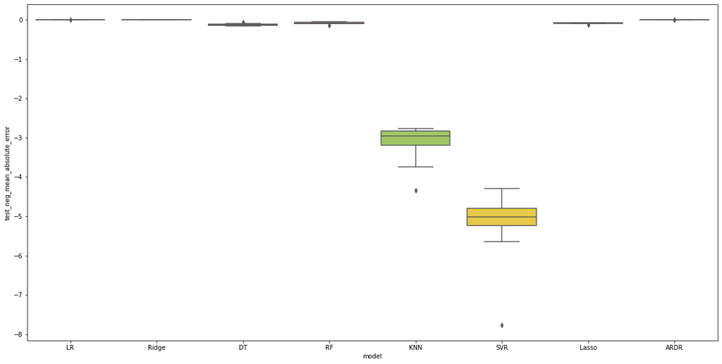

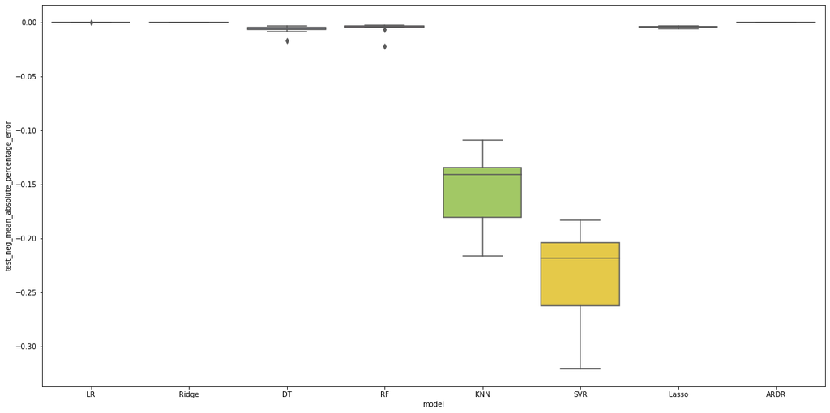

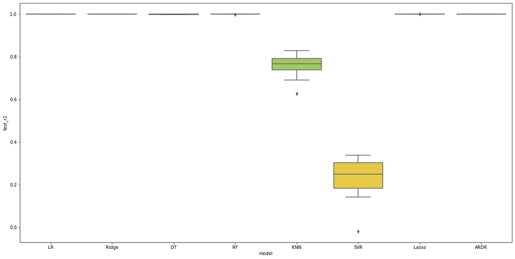

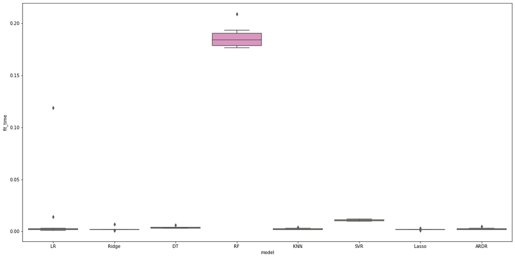

```python
plt.figure(figsize = (20, 10))
sns.boxplot(x = "model", y = "test_neg_mean_absolute_error", data = resultREG, palette = "Set2")

plt.figure(figsize = (20, 10))
sns.boxplot(x = "model", y = "test_neg_mean_absolute_percentage_error", data = resultREG, palette = "Set2")

plt.figure(figsize = (20, 10))
sns.boxplot(x = "model", y = "test_r2", data = resultREG, palette = "Set2")

plt.figure(figsize = (20, 10))
sns.boxplot(x = "model", y = "fit_time", data = resultREG, palette = "Set2")
```

Metodą eliminacji usuwaj algorytmy, które są gorsze i w ten sposób będzie można wytypować najlepszy

## Import danych i testowanie modeli klasyfikacji

```python
dataCLASS = pd.read_csv('F:\\STUDIA\\6SEM\\zpiid\\dane klasyfikacja\\penguins_size.csv')
dataCLASS.head()
```

|  | species | island | culmen_length_mm | culmen_depth_mm | flipper_length_mm | body_mass_g | sex |
| --- | --- | --- | --- | --- | --- | --- | --- |
| 0 | Adelie | Torgersen | 39.1 | 18.7 | 181.0 | 3750.0 | MALE |
| 1 | Adelie | Torgersen | 39.5 | 17.4 | 186.0 | 3800.0 | FEMALE |
| 2 | Adelie | Torgersen | 40.3 | 18.0 | 195.0 | 3250.0 | FEMALE |
| 3 | Adelie | Torgersen | NaN | NaN | NaN | NaN | NaN |
| 4 | Adelie | Torgersen | 36.7 | 19.3 | 193.0 | 3450.0 | FEMALE |

Z racji tego, że człowiek leniwy jest...

```python
dataCLASS = pd.read_csv('F:\\STUDIA\\6SEM\\zpiid\\dane klasyfikacja\\penguins_size_cleaned.csv')
dataCLASS.head()
```

|  | species | island | culmen_length_mm | culmen_depth_mm | flipper_length_mm | body_mass_g | sex |
| --- | --- | --- | --- | --- | --- | --- | --- |
| 0 | Adelie | Torgersen | 39.1 | 18.7 | 181 | 3750 | MALE |
| 1 | Adelie | Torgersen | 39.5 | 17.4 | 186 | 3800 | FEMALE |
| 2 | Adelie | Torgersen | 40.3 | 18.0 | 195 | 3250 | FEMALE |
| 3 | Adelie | Torgersen | 36.7 | 19.3 | 193 | 3450 | FEMALE |
| 4 | Adelie | Torgersen | 39.3 | 20.6 | 190 | 3650 | MALE |

```python
dataCLASS.loc[dataCLASS['culmen_length_mm'] == 'NA']
dataCLASS.loc[dataCLASS['sex'] == '.']
```

|  | species | island | culmen_length_mm | culmen_depth_mm | flipper_length_mm | body_mass_g | sex |
| --- | --- | --- | --- | --- | --- | --- | --- |

```python
dataCLASS.info()
```

```
<class 'pandas.core.frame.DataFrame'>
RangeIndex: 333 entries, 0 to 332
Data columns (total 7 columns):
 #   Column             Non-Null Count  Dtype
---  ------             --------------  -----
 0   species            333 non-null    object
 1   island             333 non-null    object
 2   culmen_length_mm   333 non-null    float64
 3   culmen_depth_mm    333 non-null    float64
 4   flipper_length_mm  333 non-null    int64
 5   body_mass_g        333 non-null    int64
 6   sex                333 non-null    object
dtypes: float64(2), int64(2), object(3)
memory usage: 18.3+ KB
```

```python
dataCLASS = dataCLASS.astype({
    'species' : str, 'island' : str, 'sex' : str
})
```

```python
XCLASS = dataCLASS.drop(['species', 'island'], axis = 1)
yCLASS = dataCLASS['species']
XCLASS = pd.get_dummies(XCLASS, columns = ['sex'])
XCLASS
```

|  | culmen_length_mm | culmen_depth_mm | flipper_length_mm | body_mass_g | sex_FEMALE | sex_MALE |
| --- | --- | --- | --- | --- | --- | --- |
| 0 | 39.1 | 18.7 | 181 | 3750 | 0 | 1 |
| 1 | 39.5 | 17.4 | 186 | 3800 | 1 | 0 |
| 2 | 40.3 | 18.0 | 195 | 3250 | 1 | 0 |
| 3 | 36.7 | 19.3 | 193 | 3450 | 1 | 0 |
| 4 | 39.3 | 20.6 | 190 | 3650 | 0 | 1 |
| ... | ... | ... | ... | ... | ... | ... |
| 328 | 47.2 | 13.7 | 214 | 4925 | 1 | 0 |
| 329 | 46.8 | 14.3 | 215 | 4850 | 1 | 0 |
| 330 | 50.4 | 15.7 | 222 | 5750 | 0 | 1 |
| 331 | 45.2 | 14.8 | 212 | 5200 | 1 | 0 |
| 332 | 49.9 | 16.1 | 213 | 5400 | 0 | 1 |

333 rows × 6 columns

```python
resultCLASS = modeleKlasyfikacyjne(XCLASS, yCLASS)
resultCLASS
```

|  | fit_time | score_time | test_accuracy | model |
| --- | --- | --- | --- | --- |
| 0 | 0.003989 | 0.001994 | 1.000000 | DTC |
| 1 | 0.001994 | 0.001995 | 1.000000 | DTC |
| 2 | 0.001996 | 0.001994 | 0.970588 | DTC |
| 3 | 0.001994 | 0.000998 | 0.969697 | DTC |
| 4 | 0.001994 | 0.001995 | 0.969697 | DTC |
| 5 | 0.001996 | 0.000997 | 0.969697 | DTC |
| 6 | 0.001994 | 0.001995 | 0.848485 | DTC |
| 7 | 0.001995 | 0.000997 | 1.000000 | DTC |
| 8 | 0.001995 | 0.000997 | 0.969697 | DTC |
| 9 | 0.001996 | 0.000997 | 1.000000 | DTC |
| 10 | 0.038895 | 0.000998 | 1.000000 | LDA |
| 11 | 0.002992 | 0.000997 | 1.000000 | LDA |
| 12 | 0.001995 | 0.001994 | 1.000000 | LDA |
| 13 | 0.001995 | 0.000997 | 1.000000 | LDA |
| 14 | 0.001995 | 0.000998 | 0.969697 | LDA |
| 15 | 0.001994 | 0.001995 | 1.000000 | LDA |
| 16 | 0.001994 | 0.000997 | 0.969697 | LDA |
| 17 | 0.002992 | 0.000997 | 1.000000 | LDA |
| 18 | 0.001995 | 0.001995 | 1.000000 | LDA |
| 19 | 0.001995 | 0.000997 | 1.000000 | LDA |
| 20 | 0.002992 | 0.001995 | 0.735294 | KNC |
| 21 | 0.001995 | 0.002993 | 0.764706 | KNC |
| 22 | 0.001994 | 0.001995 | 0.794118 | KNC |
| 23 | 0.001994 | 0.002992 | 0.909091 | KNC |
| 24 | 0.001995 | 0.001994 | 0.696970 | KNC |
| 25 | 0.001996 | 0.002991 | 0.909091 | KNC |
| 26 | 0.001995 | 0.002992 | 0.787879 | KNC |
| 27 | 0.001995 | 0.002992 | 0.727273 | KNC |
| 28 | 0.001995 | 0.001995 | 0.787879 | KNC |
| 29 | 0.001994 | 0.001995 | 0.787879 | KNC |
| 30 | 0.010971 | 0.001994 | 0.558824 | SVM |
| 31 | 0.009973 | 0.001995 | 0.500000 | SVM |
| 32 | 0.009973 | 0.001995 | 0.676471 | SVM |
| 33 | 0.008976 | 0.002992 | 0.636364 | SVM |
| 34 | 0.008976 | 0.002992 | 0.454545 | SVM |
| 35 | 0.008976 | 0.002992 | 0.666667 | SVM |
| 36 | 0.009973 | 0.001996 | 0.696970 | SVM |
| 37 | 0.009973 | 0.001995 | 0.757576 | SVM |
| 38 | 0.009974 | 0.001994 | 0.696970 | SVM |
| 39 | 0.009973 | 0.001995 | 0.424242 | SVM |
| 40 | 0.001994 | 0.001995 | 1.000000 | GNB |
| 41 | 0.001995 | 0.001995 | 1.000000 | GNB |
| 42 | 0.001995 | 0.001995 | 0.970588 | GNB |
| 43 | 0.001995 | 0.001995 | 0.969697 | GNB |
| 44 | 0.001994 | 0.000997 | 0.969697 | GNB |
| 45 | 0.002993 | 0.000997 | 0.969697 | GNB |
| 46 | 0.001995 | 0.001996 | 0.878788 | GNB |
| 47 | 0.001994 | 0.001994 | 0.939394 | GNB |
| 48 | 0.002992 | 0.000998 | 1.000000 | GNB |
| 49 | 0.001994 | 0.000998 | 1.000000 | GNB |
| 50 | 0.003988 | 0.000997 | 0.852941 | MNB |
| 51 | 0.002993 | 0.001994 | 0.735294 | MNB |
| 52 | 0.001995 | 0.002992 | 0.882353 | MNB |
| 53 | 0.001994 | 0.001995 | 0.909091 | MNB |
| 54 | 0.002992 | 0.000997 | 0.757576 | MNB |
| 55 | 0.002994 | 0.001994 | 0.818182 | MNB |
| 56 | 0.002991 | 0.000998 | 0.757576 | MNB |
| 57 | 0.002993 | 0.000998 | 0.696970 | MNB |
| 58 | 0.002991 | 0.000997 | 0.757576 | MNB |
| 59 | 0.002991 | 0.000998 | 0.878788 | MNB |

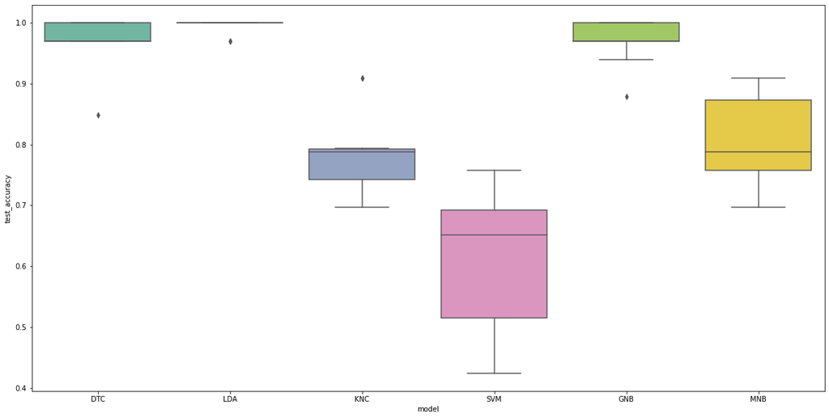

```python
plt.figure(figsize = (20, 10))
sns.boxplot(x = "model", y = "test_accuracy", data = resultCLASS, palette = "Set2")
```

## No dobrze... Walnijmy predykcje

```python
XCLASS_train, XCLASS_validation, yCLASS_train, yCLASS_validation = train_test_split(XCLASS, yCLASS, test_size = 0.2, random_state = 267, shuffle = True)
```

```python
def testyPredykcjiKlasyfikacja(XCLASS_train, XCLASS_validation, yCLASS_train, yCLASS_validation):
    predictionsArray = []
    models = [
        ('DTC', DecisionTreeClassifier()),
        ('LDA', LinearDiscriminantAnalysis()),
        ('KNC', KNeighborsClassifier()),
        ('SVM', SVC(gamma = 'auto')),
        ('GNB', GaussianNB()),
        ('MNB', MultinomialNB())]
    for prediction, model in models:
        model = model.fit(XCLASS_train, yCLASS_train)
        prediction = model.predict(XCLASS_validation)
        print(classification_report(yCLASS_validation, prediction))
```

```python
resultCLASS2 = testyPredykcjiKlasyfikacja(XCLASS_train, XCLASS_validation, yCLASS_train, yCLASS_validation)
resultCLASS2
```

```
              precision    recall  f1-score   support

      Adelie       1.00      0.88      0.94        26
   Chinstrap       0.81      1.00      0.90        13
      Gentoo       1.00      1.00      1.00        28

    accuracy                           0.96        67
   macro avg       0.94      0.96      0.95        67
weighted avg       0.96      0.96      0.96        67

              precision    recall  f1-score   support

      Adelie       1.00      1.00      1.00        26
   Chinstrap       1.00      1.00      1.00        13
      Gentoo       1.00      1.00      1.00        28

    accuracy                           1.00        67
   macro avg       1.00      1.00      1.00        67
weighted avg       1.00      1.00      1.00        67

              precision    recall  f1-score   support

      Adelie       0.74      0.88      0.81        26
   Chinstrap       0.75      0.46      0.57        13
      Gentoo       0.89      0.89      0.89        28

    accuracy                           0.81        67
   macro avg       0.79      0.75      0.76        67
weighted avg       0.81      0.81      0.80        67

              precision    recall  f1-score   support

      Adelie       0.46      1.00      0.63        26
   Chinstrap       1.00      0.15      0.27        13
      Gentoo       1.00      0.32      0.49        28

    accuracy                           0.55        67
   macro avg       0.82      0.49      0.46        67
weighted avg       0.79      0.55      0.50        67

              precision    recall  f1-score   support

      Adelie       0.96      0.92      0.94        26
   Chinstrap       0.86      0.92      0.89        13
      Gentoo       1.00      1.00      1.00        28

    accuracy                           0.96        67
   macro avg       0.94      0.95      0.94        67
weighted avg       0.96      0.96      0.96        67

              precision    recall  f1-score   support

      Adelie       0.72      0.81      0.76        26
   Chinstrap       0.70      0.54      0.61        13
      Gentoo       0.89      0.89      0.89        28

    accuracy                           0.79        67
   macro avg       0.77      0.75      0.76        67
weighted avg       0.79      0.79      0.79        67
```

## Import danych i testowanie modeli klasteryzacji

Może to być dosyć trudne z racji tego, że dane są osobliwe. Generujemy losowe punkty

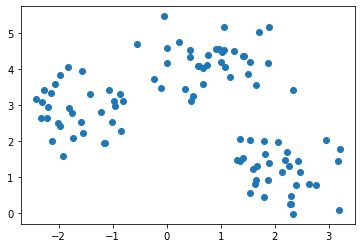

```python
XCLUST, y_true = make_blobs(n_samples=100, centers=3, cluster_std=0.60, random_state=0)
plt.scatter(XCLUST[:, 0], XCLUST[:, 1])
```

W tych przypadku wiemy ile ma być klastrów, ale często jest tak, że mamy do dysposyzcji gorzej rozlokowane dane i nie da się jasno przewidzieć dlatego trzeba skorzystać np z metody Elbow (link 3. w Źródłach)

```python
resultCLUST = KMeans(n_clusters=3, random_state=0).fit(XCLUST)
predictions = resultCLUST.predict(XCLUST)
predictions #punkt 1 należy do klastra 1, punkt 2 do 0, punkt 3 do 1, 4 do 0, 5 do 0 itd
```

```
array([1, 0, 1, 0, 0, 0, 2, 2, 1, 0, 0, 0, 1, 0, 2, 1, 2, 0, 2, 2, 2, 2,
       2, 0, 1, 1, 1, 1, 2, 2, 0, 1, 1, 0, 2, 0, 0, 1, 1, 2, 2, 1, 1, 0,
       0, 0, 1, 1, 2, 2, 0, 1, 0, 1, 2, 2, 1, 1, 0, 1, 1, 2, 2, 2, 2, 1,
       0, 2, 1, 0, 2, 0, 0, 1, 1, 0, 0, 0, 2, 1, 0, 0, 1, 0, 1, 0, 0, 0,
       1, 0, 1, 1, 2, 2, 2, 2, 0, 0, 2, 2])
```

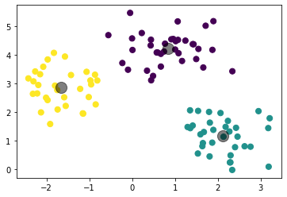

```python
plt.scatter(XCLUST[:, 0], XCLUST[:, 1], c=predictions, s=50, cmap='viridis')
centers = resultCLUST.cluster_centers_
plt.scatter(centers[:, 0], centers[:, 1], c='black', s=200, alpha=0.5);
```

```python
silhouette_score(XCLUST, predictions) #1.0 - najlepiej, mniej to gorzej
```

```
0.638644225802982
```

## To będzie trudne...

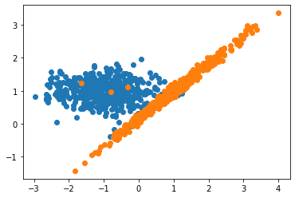

```python
XCLUST, yCLUST = make_classification(n_samples = 1000, n_features = 2, n_informative = 2, n_redundant = 0, n_clusters_per_class = 1,  random_state = 11)

for class_value in range(2):
    row_ix = where(yCLUST == class_value)
    plt.scatter(XCLUST[row_ix, 0], XCLUST[row_ix, 1])

plt.show()
```

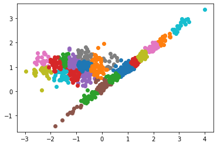

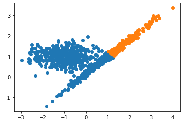

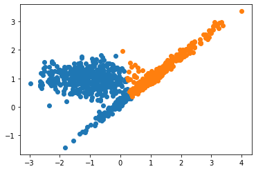

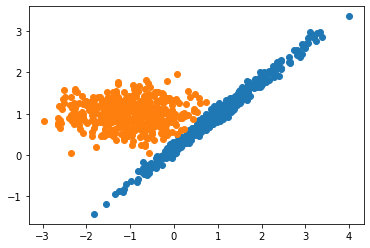

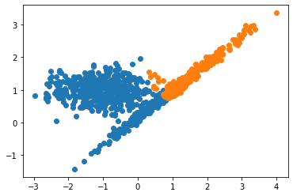

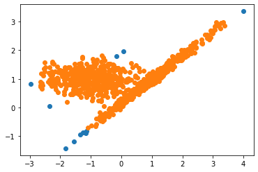

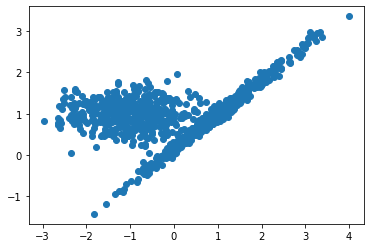

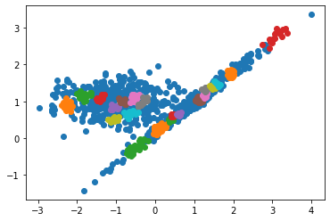

```python
#silhouette_score(XCLUST, yhat) #1.0 - najlepiej, mniej to gorzej
resultCLUST1 = modeleKlasteryzacji1(XCLUST)
resultCLUST2 = modeleKlasteryzacji2(XCLUST)
resultCLUST1
resultCLUST2
```

# Źródła

Informacje czytane:

1. Podział algorytmów https://machinelearningmastery.com/a-tour-of-machine-learning-algorithms/
2. Metryki https://scikit-learn.org/stable/modules/model_evaluation.html
3. K-Means, ELbow Method https://jakevdp.github.io/PythonDataScienceHandbook/05.11-k-means.html, https://predictivehacks.com/k-means-elbow-method-code-for-python/

Inne:

1. https://www.youtube.com/watch?v=Wo5YWXDRXv8
2. https://www.youtube.com/watch?v=Mhw_-xHVmaE
3. https://www.youtube.com/watch?v=yN7ypxC7838
4. https://www.youtube.com/watch?v=G7fPB4OHkys